# Body Size in Ray-Finned Fishes: Revisiting Bergmann’s Rule

William P. O’Connor and Christopher P. Kenaley

2023-02-08

# Introduction

The relationship between body size and latitude has been studied for almost two centuries, and it is still not fully understood(Bergmann (1847); Watt, Mitchell, and Salewski (2010)). Bergmann’s initial observations and his reasoning about the relationship has become a keystone in ecogeography, but further studies have sparked debates over the details of the rule. These debates come from the lack of a single complete translation of Bergmann’s initial paper(Watt, Mitchell, and Salewski (2010)) and developments in taxonomic classifications(Mayr (1956)). This has led to a lack of a universally accepted definition for Bergmann’s rule, and an incomplete understanding of the trend it models. Variations in the rule include the presence of a mechanism, what kind of animals it applies to, and the taxonomic scope(Watt, Mitchell, and Salewski (2010)). ### Bergmann’s Rule Definition Bergmann included a mechanism in his initial paper: “for the amount of warmth, of which an animal can raise itself above its surrounding, the relation of its volume to its surface is of course of great importance; it is thus clear, that animals, have to create less warmth in relation to their size the larger they are, to gain a certain increase in temperature above the one of their surrounding.”(Watt, Mitchell, and Salewski (2010), Bergmann (1847)) Some more recent papers have chosen to exclude this mechanism from the rule, and argued that a mechanism is not necessary for the rule to exist because of the empirical nature of Bergmann’s initial observations(Meiri (2011)) and the presence of confounding variables(Mayr (1970)). Others have argued that a mechanism is required for it to actually be of value(Watt, Mitchell, and Salewski (2010)). The organisms that this rule applies to vary, although it is accepted that Bergmann’s initial paper dealt exclusively with endotherms(Blanckenhorn and Hellriegel (2002)). The variations include restrictions to endothermic vertebrates, such as in Rensch (1938), to mammals in Angilletta and Dunham (2003), and some with no restrictions at all, like Sears and Angilletta Jr (2004). The taxonomic scope is also disputed, with some papers dealing with interspecific variations(Lindsey (1966)), some intraspecific(Heibo, Magnhagen, and Vøllestad (2005), Belk and Houston (2002), Ashton and Feldman (2003)), and some papers that look at both(Chown and Gaston (2010), Adams and Church (2008)). Several older papers choose to ignore phylogeny completely(Lindsey (1966), Fisher, Frank, and Leggett (2010)). The reasoning for this confusion is partially from Bergmann’s original study, as many of the species that he looked at have since become known as populations of the same species(Mayr (1956)). ### Evidence for Bergmann’s Rule in Ectotherms Mixed results have come from looking for evidence of a trend similar to both interspecific and intraspecific versions of Bergmann’s rule in ectotherms. Freshwater fish are a prime example of this, with a lack of trend in 18 North American species(Belk and Houston (2002)) and the European species P. Fluviatilis(Heibo, Magnhagen, and Vøllestad (2005)), but a positive correlation between latitude and size within 25 species in Europe(Blanck and Lamouroux (2007)). All of these studies look at populations of the same species, not between species. Saltwater fishes appear to exhibit the trends similar to those noted by Bergmann, with larger species occurring at more extreme latitudes, although studies that observed this trend did not account for phylogeny(Lindsey (1966), Fisher, Frank, and Leggett (2010)). Amphibians show mixed trends, with some species having populations of larger individuals near the equator, and most with larger populations near the poles(Queiroz and Ashton (2004)), and an inter- and intra-specific study of one family, Plethodon, that showed no overall relation between length and temperature(Adams and Church (2008)). Another study of amphibians with no phylogenetic consideration showed no trend in maximum length and latitude of salamanders, but it did show larger specimens at more extreme latitudes in Anurans(Lindsey (1966)). Studies of turtles have shown varying trends, with most species showing trends of increasing size with latitude, and some showing the converse trend(Queiroz and Ashton (2004)), and this holds both phylogenetically and nonphylogenetically(Ashton and Feldman (2003)). Squamates mostly do not exhibit Bergmann-like trends(Queiroz and Ashton (2004), Ashton and Feldman (2003), Pincheira-Donoso, Hodgson, and Tregenza (2008)), although European lizards tend to be larger at more extreme latitudes(Olalla-Tárraga, Rodrı́guez, and Hawkins (2006)). Latitude has an effect on the size of most insects on both the interspecific and intraspecific levels, but the direction of these trends is split fairly evenly between a positive and negative correlation(Chown and Gaston (2010), Mousseau (1997)). ### Aims of the Study Due to the ectothermic nature of most fish, the mechanism described by Bergmann does not apply. Since most of the existing studies of fishes focus on intraspecific trends, data for interspecific comparisons of average latitude and maximum length was used. That is why we are using a slight variation of the version of the rule found in Blackburn, Gaston, and Loder (1999), “Bergmann’s rule is the tendency for a positive association between the body mass of species in a monophyletic higher taxon and the latitude inhabited by those species.” One study that used a similar interpretation of the rule and maximum lengths for species was Olalla-Tárraga, Rodrı́guez, and Hawkins (2006), which looked at squamate lengths in Europe and North America, but it did not consider phylogeny. Body size in fish was studied across 5 salinity groups in Clarke (2021), and a difference in body size was noted. This difference led us to believe that a difference in the size-latitude relationship could exist among salinity groups, and is the reason salinity was selected for further analysis. It may also provide insight that would eventually lead to a mechanism, although that is not studied here.

# Methods

## Selecting species, getting data

# Results

```r
g.latT <- readRDS("total.rds")
```

[figure not shown]

```
##                             Estimate   Est.Error     l-95% CI     u-95% CI
## Intercept                4.004449857 0.665855339  2.708789250  5.327249750
## abslat                   0.012197449 0.002224051  0.007884218  0.016610822
## mar.fresh2Fresh         -0.431580124 0.084555772 -0.598350350 -0.268676275
## mar.fresh2Marine        -0.217084611 0.075576074 -0.365889250 -0.067766653
## abslat:mar.fresh2Fresh  -0.000758480 0.002629729 -0.005991690  0.004330436
## abslat:mar.fresh2Marine  0.001785527 0.002581350 -0.003324534  0.006875871
##                             Rhat Bulk_ESS Tail_ESS
## Intercept               1.008109 2401.535 3994.741
## abslat                  1.002867 4613.542 6303.200
## mar.fresh2Fresh         1.002327 4298.627 6061.722
## mar.fresh2Marine        1.001637 4354.922 6154.919
## abslat:mar.fresh2Fresh  1.001290 4854.500 6664.172
## abslat:mar.fresh2Marine 1.001729 4618.936 6575.666
```

[figure not shown]

[figure not shown]

```r
ggplot(g.latT$data, aes(x=log.L,col=mar.fresh2)) + geom_histogram(binwidth=0.5) + labs(title="Figure 1: Log Length of Sample of Species",x="Log Length", y = "Count")
```

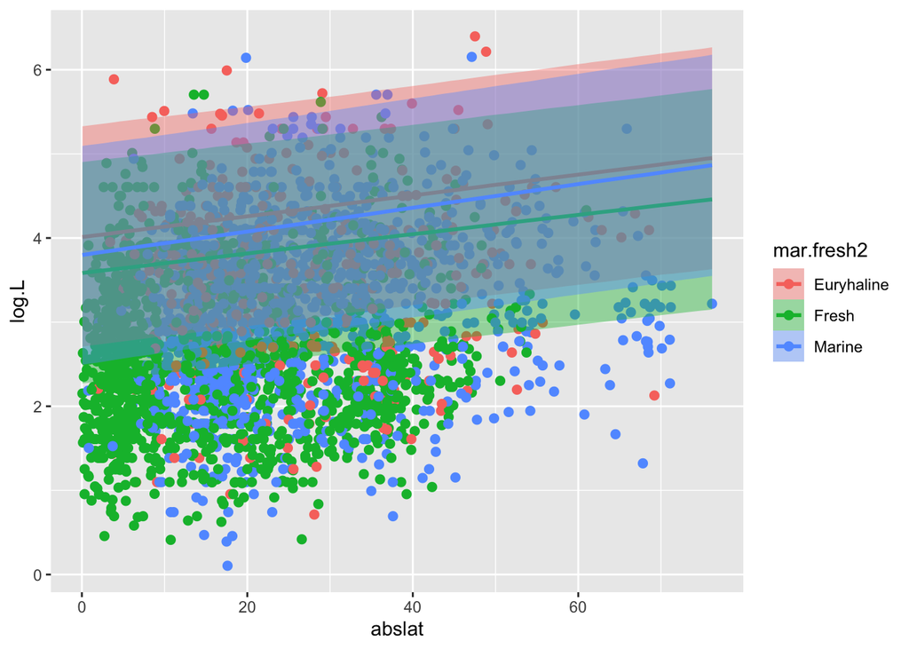

```r
#Lat v Length, with salinity - needs title or caption
p2<-plot(brms::conditional_effects(g.latT,effects="abslat:mar.fresh2"),points=T)
```

```r
p2$`abslat:mar.fresh2`$labels$x <- "Absolute Latitude"
p2$`abslat:mar.fresh2`$labels$y <- "Log (BL)"
p2$`abslat:mar.fresh2`$labels$colour<-"Salinity"
p2$`abslat:mar.fresh2`$labels$fill<-"Salinity"
p2
```

```
## $`abslat:mar.fresh2`
```

[figure not shown]

```r
#p2$`abslat:mar.fresh2`$theme <- theme_classic()
```

```r
mfe<- posterior_samples(g.latT)%>%
  transmute(dif1 = b_mar.fresh2Marine - b_mar.fresh2Fresh,dif2 = b_mar.fresh2Marine,dif3 = b_mar.fresh2Fresh)
```

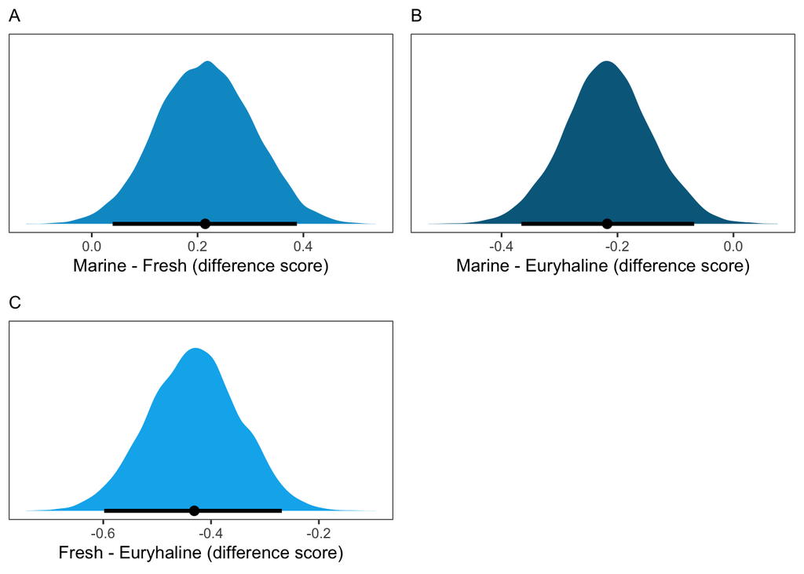

```r
pmf <- ggplot(mfe,aes(x = dif1, y = 0)) +
    stat_halfeye(fill = "deepskyblue3",
                point_interval = median_qi, .width = .95) +
  scale_y_continuous(NULL, breaks = NULL) +
  labs(subtitle = "A",
       x = expression("Marine - Fresh (difference score)")) +
  theme_bw() +
  theme(panel.grid = element_blank())
pme <- ggplot(mfe,aes(x = dif2, y = 0)) +
    stat_halfeye(fill = "deepskyblue4",
                point_interval = median_qi, .width = .95) +
  scale_y_continuous(NULL, breaks = NULL) +
  labs(subtitle = "B",
       x = expression("Marine - Euryhaline (difference score)")) +
  theme_bw() +
  theme(panel.grid = element_blank())
pfe <- ggplot(mfe,aes(x = dif3, y = 0)) +
    stat_halfeye(fill = "deepskyblue2",
                point_interval = median_qi, .width = .95) +
  scale_y_continuous(NULL, breaks = NULL) +
  labs(subtitle = "C",
       x = expression("Fresh - Euryhaline (difference score)")) +
  theme_bw() +
  theme(panel.grid = element_blank())
bayesplot_grid(pmf, pme, pfe,grid_args = list(ncol = 2))
```

Adams, Dean C, and James O Church. 2008. “Amphibians Do Not Follow Bergmann’s Rule.” *Evolution: International Journal of Organic Evolution* 62 (2): 413–20.

Angilletta, Michael J, Jr, and Arthur E Dunham. 2003. “The Temperature-Size Rule in Ectotherms: Simple Evolutionary Explanations May Not Be General.” *The American Naturalist* 162 (3): 332–42.

Ashton, Kyle G, and Chris R Feldman. 2003. “Bergmann’s Rule in Nonavian Reptiles: Turtles Follow It, Lizards and Snakes Reverse It.” *Evolution* 57 (5): 1151–63.

Belk, Mark C, and Derek D Houston. 2002. “Bergmann’s Rule in Ectotherms: A Test Using Freshwater Fishes.” *The American Naturalist* 160 (6): 803–8.

Bergmann, C. 1847. “Ober Die Verhaltnisse Der Warmeokonomie Der Thiere Zu Ihrer Grosse.” *Gottinger Studien* 3: 595–708.

Blackburn, Tim M, Kevin J Gaston, and Natasha Loder. 1999. “Geographic Gradients in Body Size: A Clarification of Bergmann’s Rule.” *Diversity and Distributions* 5 (4): 165–74.

Blanck, Aurélie, and Nicolas Lamouroux. 2007. “Large-Scale Intraspecific Variation in Life-History Traits of European Freshwater Fish.” *Journal of Biogeography* 34 (5): 862–75.

Blanckenhorn, Wolf U, and Barbara Hellriegel. 2002. “Against Bergmann’s Rule: Fly Sperm Size Increases with Temperature.” *Ecology Letters* 5 (1): 7–10.

Boettiger, Carl, D Temple Lang, and PC Wainwright. 2012. “Rfishbase: Exploring, Manipulating and Visualizing FishBase Data from r.” *Journal of Fish Biology* 81 (6): 2030–39.

Bürkner, Paul-Christian. 2017. “Brms: An r Package for Bayesian Multilevel Models Using Stan.” *Journal of Statistical Software* 80: 1–28.

Chamberlain, Scott, Damiano Oldoni, and John Waller. 2022. “Rgbif: Interface to the Global Biodiversity Information Facility API.”

Chang, Jonathan, Daniel L Rabosky, Stephen A Smith, and Michael E Alfaro. 2019. “An r Package and Online Resource for Macroevolutionary Studies Using the Ray-Finned Fish Tree of Life.” *Methods in Ecology and Evolution* 10 (7): 1118–24.

Chown, Steven L, and Kevin J Gaston. 2010. “Body Size Variation in Insects: A Macroecological Perspective.” *Biological Reviews* 85 (1): 139–69.

Clarke, John T. 2021. “Evidence for General Size-by-Habitat Rules in Actinopterygian Fishes Across Nine Scales of Observation.” *Ecology Letters* 24 (8): 1569–81.

Fisher, Jonathan AD, Kenneth T Frank, and William C Leggett. 2010. “Global Variation in Marine Fish Body Size and Its Role in Biodiversity–Ecosystem Functioning.” *Marine Ecology Progress Series* 405: 1–13.

Gelman, Andrew. 2006. “Prior Distributions for Variance Parameters in Hierarchical Models (Comment on Article by Browne and Draper).” *Bayesian Analysis* 1 (3): 515–34.

Hadfield, JD, and S Nakagawa. 2010. “General Quantitative Genetic Methods for Comparative Biology: Phylogenies, Taxonomies and Multi-Trait Models for Continuous and Categorical Characters.” *Journal of Evolutionary Biology* 23 (3): 494–508.

Heibo, Erik, Carin Magnhagen, and Leif Asbjørn Vøllestad. 2005. “Latitudinal Variation in Life-History Traits in Eurasian Perch.” *Ecology* 86 (12): 3377–86.

Housworth, Elizabeth A, Emilia P Martins, and Michael Lynch. 2004. “The Phylogenetic Mixed Model.” *The American Naturalist* 163 (1): 84–96.

Lindsey, CC. 1966. “Body Sizes of Poikilotherm Vertebrates at Different Latitudes.” *Evolution*, 456–65.

Mayr, Ernst. 1956. “Geographical Character Gradients and Climatic Adaptation.” *Evolution* 10 (1): 105–8.

———. 1970. *Populations, Species, and Evolution: An Abridgment of Animal Species and Evolution*. Vol. 19.

McElreath, Richard. 2020. *Statistical Rethinking: A Bayesian Course with Examples in r and Stan*. Chapman; Hall/CRC.

Meiri, Shai. 2011. “Bergmann’s Rule–What’s in a Name?” *Global Ecology and Biogeography* 20 (1): 203–7.

Mousseau, Timothy A. 1997. “Ectotherms Follow the Converse to Bergmann’s Rule.” *Evolution*, 630–32.

Olalla-Tárraga, Miguel Á, Miguel Á Rodrı́guez, and Bradford A Hawkins. 2006. “Broad-Scale Patterns of Body Size in Squamate Reptiles of Europe and North America.” *Journal of Biogeography* 33 (5): 781–93.

Pagel, Mark. 1994. “Detecting Correlated Evolution on Phylogenies: A General Method for the Comparative Analysis of Discrete Characters.” *Proceedings of the Royal Society of London. Series B: Biological Sciences* 255 (1342): 37–45.

Pincheira-Donoso, Daniel, David J Hodgson, and Tom Tregenza. 2008. “The Evolution of Body Size Under Environmental Gradients in Ectotherms: Why Should Bergmann’s Rule Apply to Lizards?” *BMC Evolutionary Biology* 8 (1): 1–13.

Queiroz, Alan de, and Kyle G Ashton. 2004. “The Phylogeny of a Species-Level Tendency: Species Heritability and Possible Deep Origins of Bergmann’s Rule in Tetrapods.” *Evolution* 58 (8): 1674–84.

Rensch, Bernhard. 1938. “Some Problems of Geographical Variation and Species-Formation.” In *Proceedings of the Linnean Society of London*, 150:275–85. 4. Wiley Online Library.

Roycroft, Emily J, Jonathan A Nations, and Kevin C Rowe. 2020. “Environment Predicts Repeated Body Size Shifts in a Recent Radiation of Australian Mammals.” *Evolution* 74 (3): 671–80.

Sears, Michael W, and Michael J Angilletta Jr. 2004. “Body Size Clines in Sceloporus Lizards: Proximate Mechanisms and Demographic Constraints.” *Integrative and Comparative Biology* 44 (6): 433–42.

Villemereuil, Pierre de, Jessie A Wells, Robert D Edwards, and Simon P Blomberg. 2012. “Bayesian Models for Comparative Analysis Integrating Phylogenetic Uncertainty.” *BMC Evolutionary Biology* 12 (1): 1–16.

Watt, Cortney, Sean Mitchell, and Volker Salewski. 2010. “Bergmann’s Rule; a Concept Cluster?” *Oikos* 119 (1): 89–100.